# Big Data in Biology

Practice 2 assignment: QC & Data pre-treatment

Raquel Ventura Baños

April 15, 2024

```r
setwd('C:/Users/raque/OneDrive/Documentos/Master/Big data/Big_Data_Practices_23_24/Practices/Practice_2')
library(tidyverse)
library(readxl)
library(writexl)
library(reshape2)
```

```r
library(ggrepel)
library(cowplot)
#library(rgl)
library(knitr)

## Genomic annotations:
library(biomaRt)

## Unsupervised methods for dimensionality reduction & clustering
library(Rtsne)
library(umap)
library(dendextend)
## RNA-seq quantification & Differential expression libraries.
library(tximport)
library(edgeR)
library(limma)
library(DESeq2)
library(qvalue)
library(ashr)
library(mashr)


## Useful libraries for running nerichment analyses and interpreting stats results
library(fgsea)
#library(clusterProfiler)
#library(org.Hs.eg.db)
library(AnnotationDbi)
library(msigdbr)
#library(enrichplot)
library(ggnewscale)
```

### 1. Always working on dataset 2 (Krautz), let us open some black boxes:

Pretreatment:

```r
?getBM
```

```
## starting httpd help server ... done
```

```r
reads=read.table("Analyses/Inputs/Raw_datasets/D2/reads.txt")

first_time=TRUE
if(first_time)
{
fly <- useMart(host="https://feb2021.archive.ensembl.org", biomart="ENSEMBL_MART_ENSEMBL",
dataset="dmelanogaster_gene_ensembl")
dir.create("Analyses/Inputs/Raw_datasets/D2/marts",recursive=TRUE)
save(fly,file="Analyses/Inputs/Raw_datasets/D2/marts/fly_mart.Rdata")
} else {
  load(file="Analyses/Inputs/Raw_datasets/D2/marts/fly_mart.Rdata")
}
possible_attributes=listAttributes(fly)
head(possible_attributes)
```

```
##                    name              description         page
## 1       ensembl_gene_id           Gene stable ID feature_page
## 2 ensembl_transcript_id     Transcript stable ID feature_page
## 3    ensembl_peptide_id        Protein stable ID feature_page
## 4       ensembl_exon_id           Exon stable ID feature_page
## 5           description         Gene description feature_page
## 6       chromosome_name Chromosome/scaffold name feature_page
```

```r
genes_fly = getBM(attributes = c("flybase_gene_id","start_position","end_position","chromosome_name","gene_biotype"),
filters = "flybase_gene_id", values = rownames(reads) , mart = fly)

head(genes_fly)
```

```
##   flybase_gene_id start_position end_position chromosome_name   gene_biotype
## 1     FBgn0000008       22136968     22172834              2R protein_coding
## 2     FBgn0000014       16807214     16830049              3R protein_coding
## 3     FBgn0000015       16927212     16972236              3R protein_coding
## 4     FBgn0000017       16615866     16647882              3L protein_coding
## 5     FBgn0000018       10973443     10975293              2L protein_coding
## 6     FBgn0000022         370031       370947               X protein_coding
```

```r
length(which(!(rownames(reads) %in% genes_fly$flybase_gene_id)))
```

```
## [1] 43
```

```r
rownames(genes_fly)=genes_fly$flybase_gene_id
reads=reads[which(rownames(reads) %in% rownames(genes_fly)),]

dim(genes_fly)
```

```
## [1] 14197     5
```

```r
length(unique(genes_fly$flybase_gene_id))
```

```
## [1] 14197
```

```r
genes_fly=genes_fly[order(rownames(genes_fly)),]

reads=reads[order(rownames(reads)),]

length(which(rownames(reads) != rownames(genes_fly)))
```

```
## [1] 0
```

```r
dir.create("Analyses/Inputs/Processed_datasets/D2/annotated/",recursive=TRUE)
write.table(reads,"Analyses/Inputs/Processed_datasets/D2/annotated/reads.txt")
write.table(genes_fly,"Analyses/Inputs/Processed_datasets/D2/annotated/feature_data.txt")

lengths=read.table("Analyses/Inputs/Raw_datasets/D2/lengths.txt")
tpms=read.table("Analyses/Inputs/Raw_datasets/D2/tpms.txt")
metadata=read.table("Analyses/Inputs/Raw_datasets/D2/meta_data.txt")

lengths=lengths[which(rownames(lengths) %in% rownames(reads)),]
tpms=tpms[which(rownames(tpms) %in% rownames(reads)),]

dim(lengths)
```

```
## [1] 14197    12
```

```r
dim(tpms)
```

```
## [1] 14197    12
```

```r
tpms=tpms[order(rownames(tpms)),]
lengths=lengths[order(rownames(lengths)),]

length(which(rownames(reads) != rownames(lengths)))
```

```
## [1] 0
```

```r
length(which(rownames(reads) != rownames(tpms)))
```

```
## [1] 0
```

```r
length(which(rownames(metadata) != colnames(reads)))
```

```
## [1] 0
```

```r
length(which(rownames(metadata) != colnames(lengths)))
```

```
## [1] 0
```

```r
length(which(rownames(metadata) != colnames(tpms)))
```

```
## [1] 0
```

```r
write.table(lengths,"Analyses/Inputs/Processed_datasets/D2/annotated/lengths.txt")
write.table(tpms,"Analyses/Inputs/Processed_datasets/D2/annotated/tpms.txt")
write.table(metadata,"Analyses/Inputs/Processed_datasets/D2/annotated/metadata.txt")
```

```r
## Lengths, reads, tpms, feature_data and meta_data from the annotated folder:
reads=read.table("Analyses/Inputs/Processed_datasets/D2/annotated/reads.txt")
lengths=read.table("Analyses/Inputs/Processed_datasets/D2/annotated/lengths.txt")
tpms=read.table("Analyses/Inputs/Processed_datasets/D2/annotated/tpms.txt")
genes_fly=read.table("Analyses/Inputs/Processed_datasets/D2/annotated/feature_data.txt")
metadata=read.table("Analyses/Inputs/Processed_datasets/D2/annotated/metadata.txt")

## let us check the dimensions of these objects and their conformation:

dim(reads)
```

```
## [1] 14197    12
```

```r
dim(lengths)
```

```
## [1] 14197    12
```

```r
dim(tpms)
```

```
## [1] 14197    12
```

```r
dim(metadata)
```

```
## [1] 12  4
```

```r
## compare to:
dim(genes_fly)
```

```
## [1] 14197     5
```

```r
## And just to be extra sure:
length(which(rownames(reads)==rownames(lengths)))
```

```
## [1] 14197
```

```r
length(which(rownames(reads)==rownames(tpms)))
```

```
## [1] 14197
```

```r
length(which(rownames(reads)==rownames(genes_fly)))
```

```
## [1] 14197
```

```r
## As well as:
length(which(colnames(reads)==colnames(tpms)))
```

```
## [1] 12
```

```r
length(which(colnames(reads)==colnames(lengths)))
```

```
## [1] 12
```

```r
length(which(colnames(reads)==rownames(metadata)))
```

```
## [1] 12
```

```r
unique(genes_fly$chromosome_name)
```

```
##  [1] "2R"                              "3R"
##  [3] "3L"                              "2L"
##  [5] "X"                               "Y"
##  [7] "4"                               "mitochondrion_genome"
##  [9] "Unmapped_Scaffold_8_D1580_D1567" "211000022278449"
## [11] "211000022278760"                 "211000022280328"
## [13] "rDNA"                            "211000022279188"
## [15] "211000022278279"                 "211000022280341"
## [17] "211000022280703"
```

```r
summary(factor(genes_fly$chromosome_name))
```

```
##                 211000022278279                 211000022278449
##                               1                               1
##                 211000022278760                 211000022279188
##                               1                               1
##                 211000022280328                 211000022280341
##                               1                               1
##                 211000022280703                              2L
##                               1                            2691
##                              2R                              3L
##                            2875                            2754
##                              3R                               4
##                            3438                              85
##            mitochondrion_genome                            rDNA
##                              14                               5
## Unmapped_Scaffold_8_D1580_D1567                               X
##                               2                            2241
##                               Y
##                              85
```

```r
unique(genes_fly$gene_biotype)
```

```
## [1] "protein_coding" "pseudogene"     "ncRNA"
```

```r
summary(factor(genes_fly$gene_biotype))
```

```
##          ncRNA protein_coding     pseudogene
##              1          13881            315
```

```r
indexes_to_keep=which((genes_fly$chromosome_name %in% c("2L","2R","3L","3R","4")) & (genes_fly$gene_biotype == "protein_coding"))
reads=reads[indexes_to_keep,]
lengths=lengths[indexes_to_keep,]
tpms=tpms[indexes_to_keep,]
genes_fly=genes_fly[indexes_to_keep,]
```

#### - Write a function to get tpm from fpkm, and call the results tpm_2. Compare those against tpms_1: do they match?

Retrieving fpkms with the given function get_fpkm_from_counts():

```r
get_effective_counts_from_counts <- function(counts, lengths,effective_lengths,offset=1E-6)
{
    local_lengths=effective_lengths
  for(i in 1:ncol(local_lengths))
    local_lengths[,i]=lengths

   issues_lengths=length(which(effective_lengths==0))
   if(issues_lengths>0){
       print(paste(issues_lengths," features have zero effective length: adding an arbitrary offset of ",offset," bp"))
       effective_lengths=effective_lengths+offset
   }
   eff_counts=counts*lengths/effective_lengths
   return(eff_counts)
}

get_cpm_from_counts <- function(counts,offset=1E-6)
{
    depths <- apply(counts,2,sum)
    depths_mat=matrix(rep(depths,each=nrow(counts)),ncol=ncol(counts))

    issues_depths=which(depths==0)
    if(length(issues_depths)>0){
        print(paste(issues_depths," empty libraries found; CPMs set to 0"))
    }

    cpms=1E6*counts/(depths_mat)

    if(length(issues_depths)>0)
    cpms[,issues_depths]=0

    return(cpms)
}

get_fpkm_from_counts <- function(counts, effective_lengths,offset=1E-6)
{

    issues_lengths=length(which(effective_lengths==0))
    if(issues_lengths>0){
        print(paste(issues_lengths," features have zero effective length: adding an arbitrary offset of ",offset," bp"))
        effective_lengths=effective_lengths+offset
    }

    depths <- apply(counts,2,sum)
    depths_mat=matrix(rep(depths,each=nrow(counts)),ncol=ncol(counts))

    issues_depths=which(depths==0)
    if(length(issues_depths)>0){
        print(paste(issues_depths," empty libraries found; FPKMs set to 0"))
    }

    fpkms=1E9*counts/(effective_lengths*depths_mat) #kilobase/million reads (we have counts per base-pairs)

    if(length(issues_depths)>0)
    fpkms[,issues_depths]=0

    return(fpkms)
}

get_tpm_from_counts <- function(counts, effective_lengths,offset=1E-6)
{
    issues_lengths=length(which(effective_lengths==0))
    if(issues_lengths>0){
        print(paste(issues_lengths," features have zero effective length: adding an arbitrary offset of ",offset," bp"))
        effective_lengths=effective_lengths+offset
    }
    rates = counts/effective_lengths
    denoms = apply(rates,2,sum)
    denoms_mat=matrix(rep(denoms,each=nrow(rates)),ncol=ncol(rates))
    tpms=1E6*rates/denoms_mat
    return(tpms)
}

genes_fly$lengths=genes_fly$end_position-genes_fly$start_position

ecs=get_effective_counts_from_counts(counts=reads,lengths=genes_fly$lengths,effective_lengths=lengths)
cpms=get_cpm_from_counts(counts=reads)
fpkms=get_fpkm_from_counts(counts=reads,effective_lengths=lengths)
tpms_1=get_tpm_from_counts(counts=reads,effective_lengths=lengths)
```

```r
get_tpm_from_fpkm <- function(fpkm) {
  TPM <- matrix(0, nrow = nrow(fpkm), ncol = ncol(fpkm))
  for (i in 1:ncol(fpkm)) {
    TPM[, i] <- (fpkm[, i] / sum(fpkm[, i])) * 1E6
  }
  return(TPM)
}

tpm_2=data.frame(get_tpm_from_fpkm(fpkm=fpkms))

similar_tpms=(sqrt((tpms_1-tpm_2)**2)<0.05*tpms_1)

equal_tpms=(tpm_2==tpms_1)

length(equal_tpms[equal_tpms==TRUE])/(dim(fpkms)[1]*dim(fpkms)[2])
```

```
## [1] 0.2346446
```

```r
length(similar_tpms[similar_tpms==TRUE])/(dim(fpkms)[1]*dim(fpkms)[2])
```

```
## [1] 0.7768326
```

```r
dim(tpm_2)
```

```
## [1] 11668    12
```

```r
dim(tpms_1)
```

```
## [1] 11668    12
```

```r
type(tpms_1)
```

```
## [1] "double"
```

```r
type(tpm_2)
```

```
## [1] "double"
```

```r
all.equal(tpm_2, tpms_1, check.attributes=FALSE, tolerance=0.05)
```

```
## [1] TRUE
```

#### - Re-build the entry [1,1] of the object TMM_cpms using the formula given in the theory class, and the info stored in dge$samples.

```r
filter=function(tpms,threshold,metadata,grouping_factor){
  number_of_groups=length(unique(metadata[,grouping_factor]))
  medians=tpms[,1:number_of_groups]
  colnames(medians)=unique(metadata[,grouping_factor])

  for(i in 1:number_of_groups)
    medians[,i]=0
  for(i in 1:number_of_groups)
  {
    set=which(metadata[,grouping_factor]==colnames(medians)[i])
    chunk=tpms[,set]
    medians[,i]=apply(chunk,1,median)
    }
  medians$max_median=apply(medians,1,max)
  genes_to_keep=rownames(medians)[which(medians$max_median>threshold)]
  return(genes_to_keep)
}

genes_to_keep=filter(tpms=tpms,threshold=1,metadata=metadata,grouping_factor="Condition")
genes_fly=genes_fly[genes_to_keep,]

filtered_reads=reads[genes_to_keep,]
filtered_lengths=lengths[genes_to_keep,]
filtered_tpms=tpms[genes_to_keep,]

filtered_ecs=ecs[genes_to_keep,]
filtered_cpms=cpms[genes_to_keep,]
filtered_fpkms=fpkms[genes_to_keep,]
filtered_tpms_1=tpms_1[genes_to_keep,]


dge <- DGEList(counts = filtered_reads)
dge <- calcNormFactors(dge)

v=voom(dge)
TMM_cpms=v$E

prod(dge$samples$norm.factors)
```

```
## [1] 1
```

Re-building the entrance [1,1]

```r
dge$samples
```

```
##                        group lib.size norm.factors
## CTL_1                      1 23795729    0.6984228
## CTL_2                      1 29259225    0.8230192
## CTL_3                      1 22747022    0.8302072
## HYPERT_1                   1 28965517    1.0472395
## HYPERT_2                   1 29342539    1.0698679
## HYPERT_3                   1 27142776    1.1114711
## PLUS_HYPERT_1              1 38643109    1.0419838
## PLUS_HYPERT_2              1 27062598    1.0772227
## PLUS_HYPERT_3              1 24499696    1.0681331
## PROXIMAL_PLUS_HYPERT_1     1 23877386    1.1557593
## PROXIMAL_PLUS_HYPERT_2     1 57751907    1.0554056
## PROXIMAL_PLUS_HYPERT_3     1 24562128    1.1506206
```

```r
TMM_cpms[1,1]
```

```
## [1] 6.049735
```

```r
TMM1=log2(10**6*((reads[rownames(reads)==rownames(TMM_cpms)[1],1]+0.5)/(dge$samples[1,3]*sum(reads[,1])+1)))
TMM1
```

```
## [1] 6.048168
```

```r
TMM_cpms[1,1]=TMM1
```

### 2. Apply what you have learnt to leave dataset 3 (ENCODE) ready for further analyses:

```r
?getLDS

## Load the datasets
mouse_name=load("Analyses/Inputs/Raw_datasets/D3/txi_mouse.Rdata")
human_name=load("Analyses/Inputs/Raw_datasets/D3/txi_human.Rdata")

counts_human=txi_human$counts
counts_mouse=txi_mouse$counts

remove_versions=function(x){
    extract=function(i){strsplit(rownames(x)[i], "[.]")[[1]][1]}
    genes=sapply(1:nrow(x),extract)
    rownames(x)=genes
    return(x)
    }

counts_human=remove_versions(counts_human)
counts_mouse=remove_versions(counts_mouse)

first_time_D3=TRUE
if(first_time_D3)
{
mouse <- useMart(host="https://jan2019.archive.ensembl.org", biomart="ENSEMBL_MART_ENSEMBL", dataset="mmusculus_gene_ensembl")
human <- useMart(host="https://jan2019.archive.ensembl.org", biomart="ENSEMBL_MART_ENSEMBL", dataset="hsapiens_gene_ensembl")

## And we will save them, just in case

dir.create("Analyses/Inputs/Raw_datasets/D3/marts",recursive=TRUE)
save(mouse,file="Analyses/Inputs/Raw_datasets/D3/marts/mouse.Rdata")
save(human,file="Analyses/Inputs/Raw_datasets/D3/marts/human.Rdata")

}else{
  load(file="Analyses/Inputs/Raw_datasets/D3/marts/mouse.Rdata")
  load(file="Analyses/Inputs/Raw_datasets/D3/marts/human.Rdata")
}
```

```r
## Now, call getLDS to retrieve tehe (raw) ID mappings:

genes_map = getLDS(attributes = c("ensembl_gene_id","mgi_symbol"), filters = "ensembl_gene_id", values=rownames(counts_mouse) , mart = mouse, attributesL = c("ensembl_gene_id","hgnc_symbol"), martL = human, uniqueRows=T)

## Check the looks of this file: are the mappings unique?
head(genes_map)
```

```
##       Gene.stable.ID MGI.symbol Gene.stable.ID.1 HGNC.symbol
## 1 ENSMUSG00000022382      Wnt7b  ENSG00000188064       WNT7B
## 2 ENSMUSG00000064358     mt-Co3  ENSG00000198938      MT-CO3
## 3 ENSMUSG00000055723      Rras2  ENSG00000133818       RRAS2
## 4 ENSMUSG00000064370    mt-Cytb  ENSG00000198727      MT-CYB
## 5 ENSMUSG00000064357    mt-Atp6  ENSG00000198899     MT-ATP6
## 6 ENSMUSG00000064367     mt-Nd5  ENSG00000198786      MT-ND5
```

```r
genes_map$map=paste0(genes_map$Gene.stable.ID.1,"_",genes_map$Gene.stable.ID)
length(unique(genes_map$map))
```

```
## [1] 24777
```

```r
dim(genes_map)
```

```
## [1] 24781     5
```

```r
## Mappings ensemble-ensemble are not unique in this table, are bijective? No:

dupes_mouse=unique(genes_map$Gene.stable.ID[which(duplicated(genes_map$Gene.stable.ID))])
length(dupes_mouse)
```

```
## [1] 1408
```

```r
dupes_human=unique(genes_map$Gene.stable.ID.1[which(duplicated(genes_map$Gene.stable.ID.1))])


genes_map=genes_map[which(   !(genes_map$Gene.stable.ID %in% dupes_mouse)  &  !(genes_map$Gene.stable.ID.1 %in% dupes_human)),]
dim(genes_map)
```

```
## [1] 15842     5
```

```r
length(unique(genes_map$Gene.stable.ID))
```

```
## [1] 15842
```

```r
length(unique(genes_map$Gene.stable.ID.1))
```

```
## [1] 15842
```

```r
length(unique(genes_map$MGI.symbol))
```

```
## [1] 15830
```

```r
non_unequivocal_mouse_names=genes_map$MGI.symbol[which(duplicated(genes_map$MGI.symbol))]
genes_map$MGI.symbol[which(genes_map$MGI.symbol %in% non_unequivocal_mouse_names)]=genes_map$Gene.stable.ID[which(genes_map$MGI.symbol %in% non_unequivocal_mouse_names)]

length(unique(genes_map$MGI.symbol))
```

```
## [1] 15842
```

```r
## Now all are different
length(which(genes_map$MGI.symbol==""))
```

```
## [1] 0
```

```r
## Also, there are no gaps.
length(unique(genes_map$HGNC.symbol))
```

```
## [1] 15786
```

```r
non_unequivocal_human_names=genes_map$HGNC.symbol[which(duplicated(genes_map$HGNC.symbol))]

genes_map$HGNC.symbol[which(genes_map$HGNC.symbol %in% non_unequivocal_human_names)]=genes_map$Gene.stable.ID.1[which(genes_map$HGNC.symbol %in% non_unequivocal_human_names)]

length(unique(genes_map$HGNC.symbol))
```

```
## [1] 15842
```

```r
## Now all are diofferent
length(which(genes_map$HGNC.symbol==""))
```

```
## [1] 0
```

```r
## Also, there are no gaps.

## So, now, all mappings should be bijective.
length(unique(genes_map$Gene.stable.ID))
```

```
## [1] 15842
```

```r
length(unique(genes_map$Gene.stable.ID.1))
```

```
## [1] 15842
```

```r
length(unique(genes_map$MGI.symbol))
```

```
## [1] 15842
```

```r
length(unique(genes_map$HGNC.symbol))
```

```
## [1] 15842
```

```r
## Let us save the resulting table:
genes_map=genes_map[,1:4]
colnames(genes_map)=c("Ensembl_mouse","Gene_name_mouse","Ensembl_human","Gene_name_human")
write.table(genes_map,"Analyses/Inputs/Raw_datasets/D3/feature_data_mapping.txt")

length_mouse <- remove_versions(txi_mouse$length)
length_human <- remove_versions(txi_human$length)
```

#### - Use the gene-map generated between mouse and human gene IDs to select the ortholog genes whose expression can be safely compared across species. Put them into a single matrix appending, column wise, all samples alike: human, and mouse. Use human HUGO names as row IDs (gene_name_human), and harmonize the entire dataset (gene_mapping file, complete reads data, tpms, effective lengths, and metadata).

Identifying and removing undesired genes: Retrieving the mapped gene rows for humans and mouse separately:

```r
index_mapped_h <- rownames(length_human) %in% genes_map[,3]
index_keep_h <- which(index_mapped_h)

length(index_keep_h)
```

```
## [1] 15841
```

```r
index_mapped_m <- rownames(length_mouse) %in% genes_map[,1]
index_keep_m <- which(index_mapped_m)

length(index_keep_m)
```

```
## [1] 15842
```

Selecting those that are common.Notice that in this step we may lost some valuable information if we want to extract conclusions about species and tissues afterwards since this selection may include highly expressed genes for each specie that are not orthologs.

```r
index_mapped <- index_keep_m %in% index_keep_h
index_keep <- which(index_mapped)

length(index_keep)
```

```
## [1] 12382
```

```r
all.equal(rownames(counts_human[index_keep,]), rownames(length_human[index_keep,]))
```

```
## [1] TRUE
```

```r
all.equal(rownames(counts_mouse[index_keep,]), rownames(length_mouse[index_keep,]))
```

```
## [1] TRUE
```

Calculating lengths and effective lengths of mouse and human reads:

```r
length <- cbind(length_human[index_keep,], length_mouse[index_keep,])

counts <- cbind(counts_human[index_keep,], counts_mouse[index_keep,])

get_effective_lengths <- function(lengths, offset=10E-6){

   effective_lengths<-lengths

   issues_lengths=length(which(effective_lengths==0))
   if(issues_lengths>0){
       print(paste(issues_lengths," features have zero effective length: adding an arbitrary offset of ",offset," bp"))
       effective_lengths=effective_lengths+offset
   }
   return(effective_lengths)
}

effective_length <-get_effective_lengths(length)
```

We perform the same calculations we made before to obtain tpms, cpms, fpkms and effective counts:

```r
get_effective_counts_from_counts <- function(counts, lengths, effective_lengths,offset=1E-6)
{
    local_lengths=effective_lengths
  for(i in 1:ncol(local_lengths))
    local_lengths[,i]=lengths[,i]

   issues_lengths=length(which(effective_lengths==0))
   if(issues_lengths>0){
       print(paste(issues_lengths," features have zero effective length: adding an arbitrary offset of ",offset," bp"))
       effective_lengths=effective_lengths+offset
   }
   eff_counts=counts*lengths/effective_lengths
   return(eff_counts)
}

get_cpm_from_counts <- function(counts,offset=1E-6)
{
    depths <- apply(counts,2,sum)
    depths_mat=matrix(rep(depths,each=nrow(counts)),ncol=ncol(counts))

    issues_depths=which(depths==0)
    if(length(issues_depths)>0){
        print(paste(issues_depths," empty libraries found; CPMs set to 0"))
    }

    cpms=1E6*counts/(depths_mat)

    if(length(issues_depths)>0)
    cpms[,issues_depths]=0

    return(cpms)
}

get_fpkm_from_counts <- function(counts, effective_lengths,offset=1E-6)
{

    issues_lengths=length(which(effective_lengths==0))
    if(issues_lengths>0){
        print(paste(issues_lengths," features have zero effective length: adding an arbitrary offset of ",offset," bp"))
        effective_lengths=effective_lengths+offset
    }

    depths <- apply(counts,2,sum)
    depths_mat=matrix(rep(depths,each=nrow(counts)),ncol=ncol(counts))

    issues_depths=which(depths==0)
    if(length(issues_depths)>0){
        print(paste(issues_depths," empty libraries found; FPKMs set to 0"))
    }

    fpkms=1E9*counts/(effective_lengths*depths_mat) #kilobase/million reads (we have counts per base-pairs)

    if(length(issues_depths)>0)
    fpkms[,issues_depths]=0

    return(fpkms)
}

get_tpm_from_counts <- function(counts, effective_lengths,offset=1E-6)
{
    issues_lengths=length(which(effective_lengths==0))
    if(issues_lengths>0){
        print(paste(issues_lengths," features have zero effective length: adding an arbitrary offset of ",offset," bp"))
        effective_lengths=effective_lengths+offset
    }
    rates = counts/effective_lengths
    denoms = apply(rates,2,sum)
    denoms_mat=matrix(rep(denoms,each=nrow(rates)),ncol=ncol(rates))
    tpms=1E6*rates/denoms_mat
    return(tpms)
}

effective_counts_mouse <- get_effective_counts_from_counts(counts, length, effective_length)
cpms <- get_cpm_from_counts(counts)
tpms <- get_tpm_from_counts(counts, effective_length)
fpkms <- get_fpkm_from_counts(counts, effective_length)
```

Creating the data frame with the HGCN names for each gene and tpms, fpkms, cpms, effective lengths and metadata.

Harmonizing the dataset: Notice that genes can be deleted in this step due to the lack of HUGO names for some genes that we don’t know if they could be highly expressed.

```r
index_name <- rownames(length) %in% genes_map[,3]
index_HGNC_measures<- which(index_name)
dim(length[index_HGNC_measures,])
```

```
## [1] 10742    26
```

```r
index_name <- genes_map[,3] %in% rownames(length)
index_HGNC_genes_map<- which(index_name)
dim(genes_map[index_HGNC_genes_map,])
```

```
## [1] 10742     4
```

```r
# I assure that rownames for different measures is equal
all.equal(rownames(counts[index_HGNC_measures,]), rownames(length[index_HGNC_measures,]))
```

```
## [1] TRUE
```

```r
# I assure that names for counts and the mapping also coincide
all.equal(sort(rownames(counts[index_HGNC_measures,])),sort(genes_map[index_HGNC_genes_map,3]))
```

```
## [1] TRUE
```

```r
genes_map <- genes_map[index_HGNC_genes_map,]
genes_map <- genes_map[order(genes_map[,3]),]
```

```r
new_row_names <- genes_map[, 4]

rownames(length) <- NULL
rownames(counts) <- NULL
rownames(tpms) <- NULL
rownames(cpms) <- NULL
rownames(fpkms) <- NULL
rownames(effective_length) <- NULL

length <- cbind(new_row_names, length)
counts <- cbind(new_row_names, counts)
tpms <- cbind(new_row_names, tpms)
cpms <- cbind(new_row_names, cpms)
fpkms <- cbind(new_row_names, fpkms)
effective_length <- cbind(new_row_names, effective_length)
```

```r
head(length)
```

```
##   new_row_names human_adipose human_adrenal human_brain human_heart
## 1        TSPAN6      2001.725      2074.230    2153.425    2139.913
## 2         SCYL3      4152.803      3993.981    4407.065    4148.750
## 3      C1orf112      2262.756      2311.189    2890.103    3132.021
## 4         FUCA2      2101.228      2132.851    1973.837    2020.133
## 5          GCLC      2222.636      1983.307    3171.223    2728.385
## 6          NFYA      3394.070      2933.395    3636.710    3645.500
##   human_kidney human_liver human_lung human_ovary human_pancreas
## 1     2128.616    2073.633   2101.516    1941.823       2106.173
## 2     4402.465    4153.258   4337.052    3616.718       4639.622
## 3     3838.801    3341.501   3668.966    3041.947       3391.514
## 4     2169.306    2143.662   2144.803    2070.933       2168.194
## 5     3253.616    2720.033   3215.196    2078.740       3115.229
## 6     3647.130    3575.637   3583.527    3435.067       3638.500
##   human_sigmoid_colon human_small_bowel human_spleen human_testis mouse_adipose
```

[output cut: 27 more lines]

```r
head(counts)
```

```
##   new_row_names human_adipose human_adrenal human_brain human_heart
## 1        TSPAN6      822.6164     1574.7056    190.4023    375.9438
## 2         SCYL3      311.7126     1200.1243    131.2849    435.7245
## 3      C1orf112      104.8256      226.9906    390.0102    142.3572
## 4         FUCA2      688.4116     5152.7517    824.6742   1335.6367
## 5          GCLC     1035.9481     6169.8017   1250.9951   1517.5526
## 6          NFYA      379.9996     1798.9990    821.0000    405.0000
##   human_kidney human_liver human_lung human_ovary human_pancreas
## 1   1146.64400   2607.8930   930.9518   3182.5662      395.65050
## 2    177.21920    567.0546   481.0554    634.6621      304.21228
## 3     27.78086    170.6315   180.8158    297.1028       61.10245
## 4   1143.28144   1664.2116  1932.3631   3062.0262      620.82813
## 5    549.00063   4144.2333  1123.0004   2134.0294      797.94029
## 6    131.00000    489.9995   492.9998   1599.9951      305.00000
##   human_sigmoid_colon human_small_bowel human_spleen human_testis mouse_adipose
```

[output cut: 27 more lines]

#### - Once you got the harmonized dataset, complete the same QC process that we executed here on dataset 3. In the low-expression filtering step, discard only the genes whose median tpm is lower than 1 simultaneously in the mouse samples, on the one hand, and on the human samples, on the other hand. Here, let us focus, specifically, on the results obtained from the hierarchical clustering. What is your conclusion? What do you think are the general implications of this analysis in this particular case?

Filtering tpms < 1 for both species.

```r
for (i in 1:length(tpms[,1])) {
  tpms[i,28]<- mean(t(tpms[i,2:14]))
  tpms[i,29]<- mean(t(tpms[i,15:27]))
}
```

```r
index_tpms_1 <- which(tpms[,28]>1 & tpms[,29]>1)
```

```r
length <-length[index_tpms_1,]
counts <-counts[index_tpms_1,]
tpms <-tpms[index_tpms_1,1:27]
cpms <-cpms[index_tpms_1,]
fpkms <-fpkms[index_tpms_1,]
effective_length <-effective_length[index_tpms_1,]
```

Clustering

```r
dge <- DGEList(counts = counts)
```

```
## Setting first column of `counts` as gene annotation.
```

```r
dge <- calcNormFactors(dge)

v=voom(dge)
TMM_cpms=v$E

clusters <- hclust(dist(t(TMM_cpms)))
clusterCut <- cutree(clusters, 3)

clusterCut
```

```
##       human_adipose       human_adrenal         human_brain         human_heart
##                   1                   1                   1                   1
##        human_kidney         human_liver          human_lung         human_ovary
##                   1                   1                   1                   1
##      human_pancreas human_sigmoid_colon   human_small_bowel        human_spleen
##                   1                   1                   1                   1
##        human_testis       mouse_adipose       mouse_adrenal         mouse_brain
##                   1                   2                   2                   3
##         mouse_heart        mouse_kidney         mouse_liver          mouse_lung
##                   2                   2                   2                   2
##         mouse_ovary      mouse_pancreas mouse_sigmoid_colon   mouse_small_bowel
##                   2                   2                   2                   2
##        mouse_spleen        mouse_testis
##                   2                   3
```

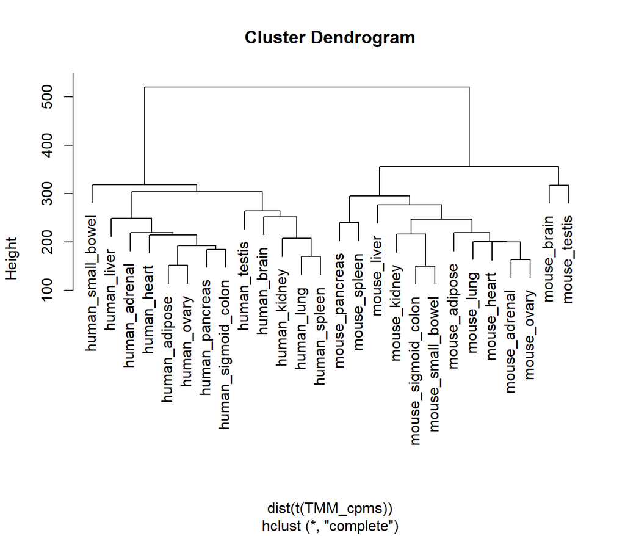

```r
plot(clusters)
```

Mouse an human are clustered separately and both tissues clusters are not comparable with each other. In this cluster I can’t see any relation between tissues or species for genes since are really differentiated. Data obtained after all the treatment and filtering leads to the conclusion that specie is the principal factor contributing differentiation the expression level of each gene while differences between tissues are smaller. Furthermore, even the internal structure of the two superior branches isn’t as similar as we may expect.

### 3. Reproduce the pipeline above on dataset 1 (Quach), and discuss the results. In the low-expression filtering step, use tpms calculated from annotated gene lengths in the feature data table (instead of based on effective lengths per gene and sample, which we do not have here). Then, define ten groups: one per condition, within each ethnicity group (AF and EU), and discard only the genes whose median tpm is lower than 1 simultaneously in all the ten groups at once. If you find issues with the samples (e.g. samples that are clear outliers after a PCA, or whose conditions are scrambled), propose a solution for them, and iterate. How many genes and samples do you think you should stick with for downstream analyses?

```r
feature=read.table("Analyses/Inputs/Raw_datasets/D1/featuredata.txt")
metadata=read.table("Analyses/Inputs/Raw_datasets/D1/metadata.txt")
reads=read.table("Analyses/Inputs/Raw_datasets/D1/reads.txt")
```

```r
get_tpm_from_counts <- function(counts, effective_lengths,offset=1E-6)
{
    issues_lengths=length(which(effective_lengths==0))
    if(issues_lengths>0){
        print(paste(issues_lengths," features have zero effective length: adding an arbitrary offset of ",offset," bp"))
        effective_lengths=effective_lengths+offset
    }
    rates = counts/effective_lengths
    denoms = apply(rates,2,sum)
    denoms_mat=matrix(rep(denoms,each=nrow(rates)),ncol=ncol(rates))
    tpms=1E6*rates/denoms_mat
    return(tpms)
}
```

```r
tpms <- get_tpm_from_counts(reads, feature$length)
```

Filtering:

```r
filter=function(tpms,threshold,metadata,grouping_factor){
  number_of_groups=length(unique(metadata[,grouping_factor]))
  medians=tpms[,1:number_of_groups]
  colnames(medians)=unique(metadata[,grouping_factor])

  for(i in 1:number_of_groups)
    medians[,i]=0
  for(i in 1:number_of_groups)
  {
    set=which(metadata[,grouping_factor]==colnames(medians)[i])
    chunk=tpms[,set]
    medians[,i]=apply(chunk,1,median)
    }
  medians$max_median=apply(medians,1,max)
  genes_to_keep=rownames(medians)[which(medians$max_median>threshold)]
  return(genes_to_keep)
}
```

```r
genes_to_keep=filter(tpms=tpms,threshold=1,metadata=metadata,"condition")

filtered_reads <- reads[rownames(reads) %in% genes_to_keep,]
filtered_feature <- feature[rownames(feature) %in% genes_to_keep,]
filtered_tpms<- tpms[rownames(tpms) %in% genes_to_keep,]
```

Checking dimensions

```r
dim(filtered_reads)
```

```
## [1] 10642   970
```

```r
dim(filtered_feature)
```

```
## [1] 10642     7
```

```r
dim(filtered_tpms)
```

```
## [1] 10642   970
```

PCA analysis:

```r
dge <- DGEList(counts = filtered_reads)
dge <- calcNormFactors(dge)

v=voom(dge)
TMM_cpms=v$E
```

```r
pca <-prcomp(t(TMM_cpms))
summary_pca=data.frame(summary(pca)$importance[,c(1:5)])

data<- data.frame(pca$x)

data <- data.frame(pca$x)
colnames(data)=paste0("PC",c(1:ncol(data)))

data=cbind(metadata,data[,1:6])
```

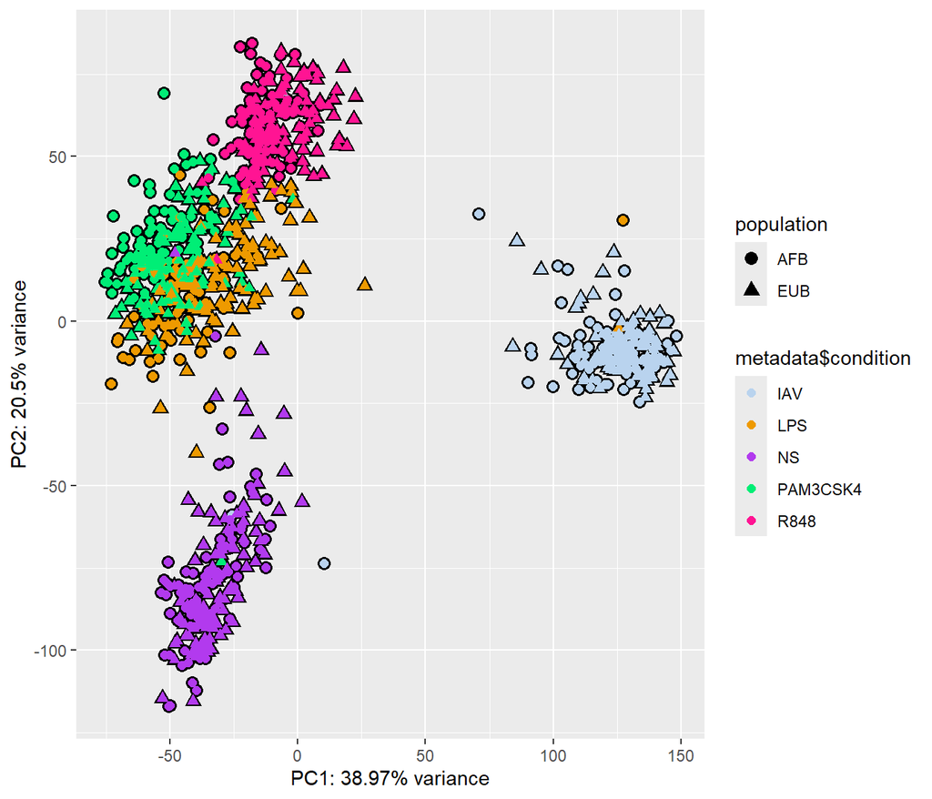

```r
colors_base=c("slategray2", "orange2","darkorchid2","springgreen2", "deeppink")

PC1PC2_plot=ggplot(data)+
  geom_point(aes(x=PC1,y=PC2, shape=population),size=3, color='black', stroke=0.5)+
  geom_point(aes(x=PC1,y=PC2,color=metadata$condition, shape=population),size=2)+
  scale_colour_manual(values=colors_base)+
  xlab(paste0("PC1: ",round(100*summary_pca$PC1[2],digits=2),"% variance"))+
  ylab(paste0("PC2: ",round(100*summary_pca$PC2[2],digits=2),"% variance"))

PC1PC2_plot
```

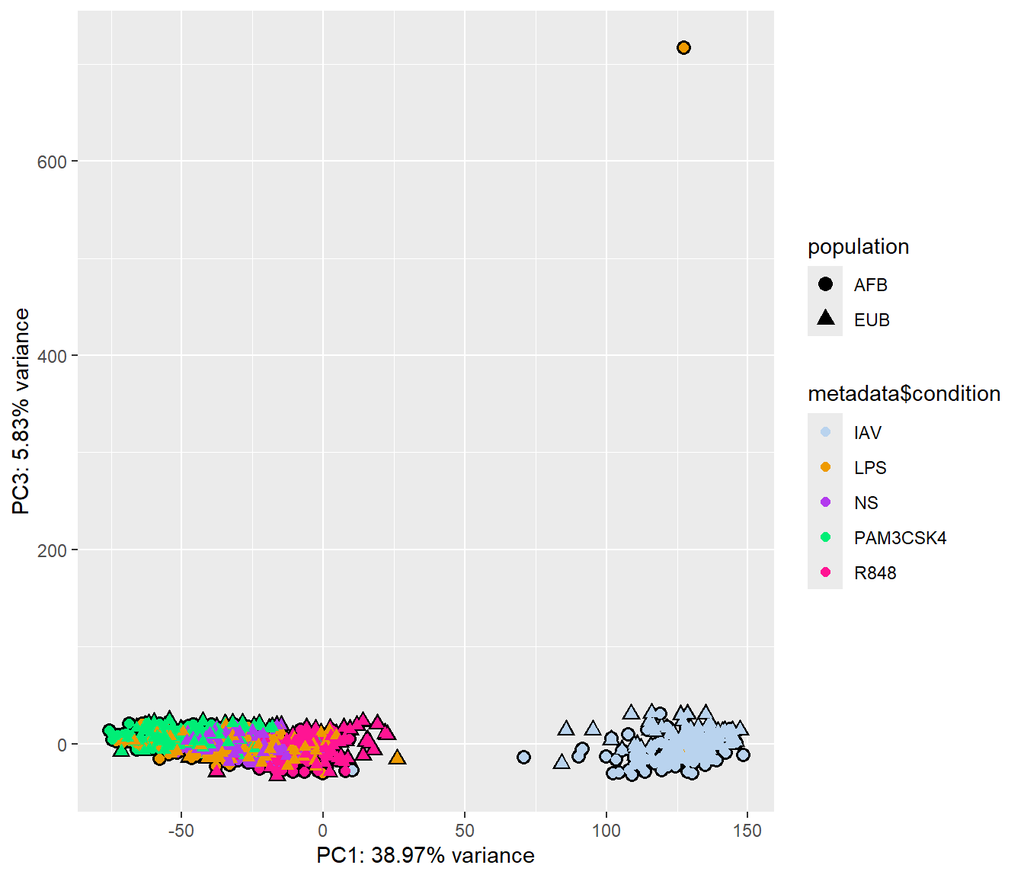

```r
PC1PC3_plot=ggplot(data)+
  geom_point(aes(x=PC1,y=PC3, shape=population),size=3, color='black', stroke=0.5)+
  geom_point(aes(x=PC1,y=PC3,color=metadata$condition, shape=population),size=2)+
  scale_colour_manual(values=colors_base)+
  xlab(paste0("PC1: ",round(100*summary_pca$PC1[2],digits=2),"% variance"))+
  ylab(paste0("PC3: ",round(100*summary_pca$PC3[2],digits=2),"% variance"))

PC1PC3_plot
```

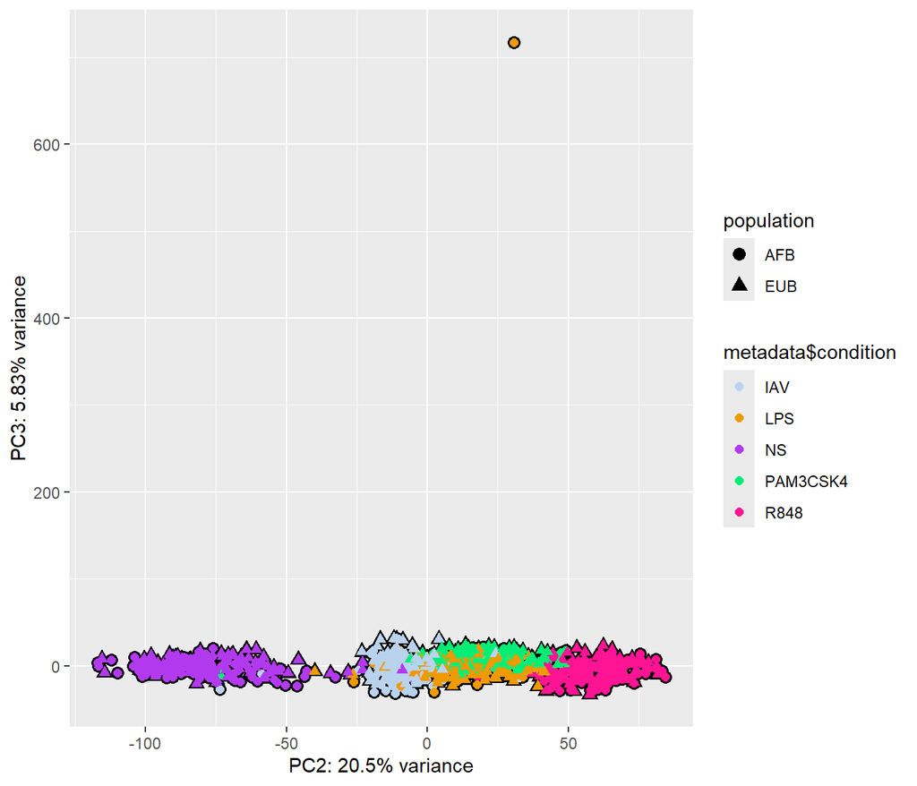

```r
PC2PC3_plot=ggplot(data)+
  geom_point(aes(x=PC2,y=PC3, shape=population),size=3, color='black', stroke=0.5)+
  geom_point(aes(x=PC2,y=PC3,color=metadata$condition, shape=population),size=2)+
  scale_colour_manual(values=colors_base)+
  xlab(paste0("PC2: ",round(100*summary_pca$PC2[2],digits=2),"% variance"))+
  ylab(paste0("PC3: ",round(100*summary_pca$PC3[2],digits=2),"% variance"))

PC2PC3_plot
```

```r
which(data$PC3>600)
```

```
## [1] 100
```

```r
data_remove <- data[-100,]
metadata_remove <- metadata[-100,]
```

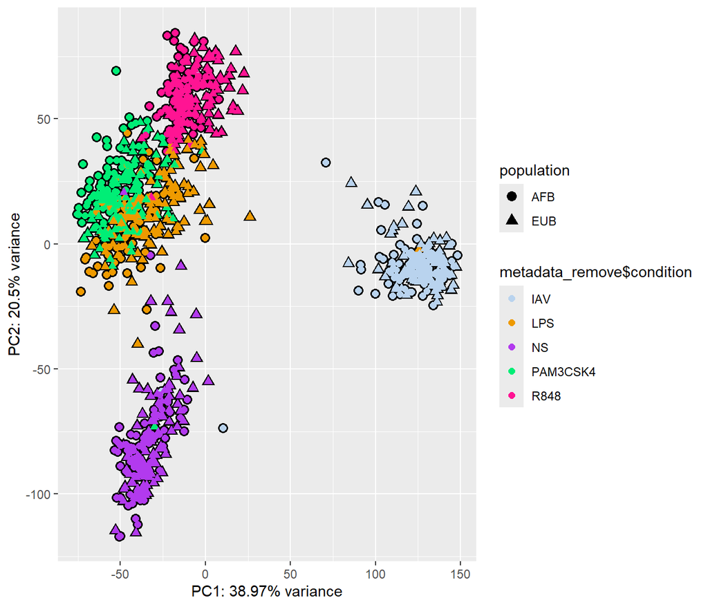

```r
PC1PC2_plot=ggplot(data_remove)+
  geom_point(aes(x=PC1,y=PC2, shape=population),size=3, color='black', stroke=0.5)+
  geom_point(aes(x=PC1,y=PC2,color=metadata_remove$condition, shape=population),size=2)+
  scale_colour_manual(values=colors_base)+
  xlab(paste0("PC1: ",round(100*summary_pca$PC1[2],digits=2),"% variance"))+
  ylab(paste0("PC2: ",round(100*summary_pca$PC2[2],digits=2),"% variance"))

PC1PC2_plot
```

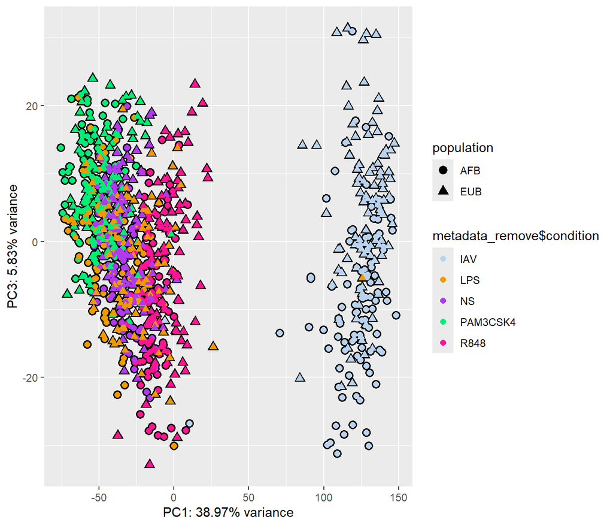

```r
PC1PC3_plot=ggplot(data_remove)+
  geom_point(aes(x=PC1,y=PC3, shape=population),size=3, color='black', stroke=0.5)+
  geom_point(aes(x=PC1,y=PC3,color=metadata_remove$condition, shape=population),size=2)+
  scale_colour_manual(values=colors_base)+
  xlab(paste0("PC1: ",round(100*summary_pca$PC1[2],digits=2),"% variance"))+
  ylab(paste0("PC3: ",round(100*summary_pca$PC3[2],digits=2),"% variance"))

PC1PC3_plot
```

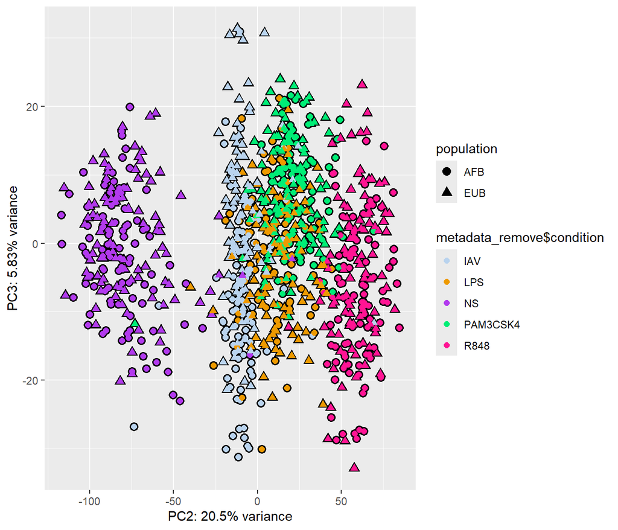

```r
PC2PC3_plot=ggplot(data_remove)+
  geom_point(aes(x=PC2,y=PC3, shape=population),size=3, color='black', stroke=0.5)+
  geom_point(aes(x=PC2,y=PC3,color=metadata_remove$condition, shape=population),size=2)+
  scale_colour_manual(values=colors_base)+
  xlab(paste0("PC2: ",round(100*summary_pca$PC2[2],digits=2),"% variance"))+
  ylab(paste0("PC3: ",round(100*summary_pca$PC3[2],digits=2),"% variance"))

PC2PC3_plot
```

This PCA analysis doesn’t show a difference between populations, there’s a clear difference for the response to conditions, and a marked difference of expression for IAV conditions form the rest.